# Time Series Analysis

AIC값이 ARIMA(1,0,2):142.4, ARIMA(2,0,2):144.38으로 앞서 보왔던 모든 모델 중에서 ARIMA(1,0,2)모델이 가장 작은 AIC값을 가지고 있는 것을 알 수 있습니다. ARIMA(2,0,2) 또한 그 다음으로 가장 작습니다.

두 모델이 정상성을 만족하고 잔차가 정규성을 지니고 독립인지 확인해보도록 하겠습니다.

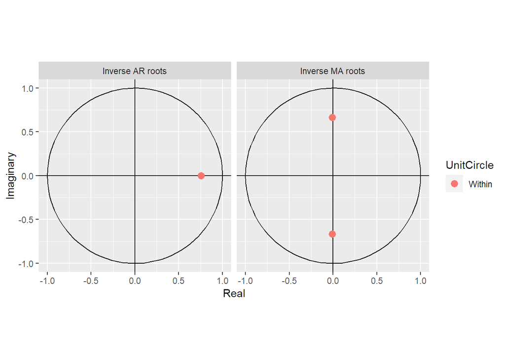

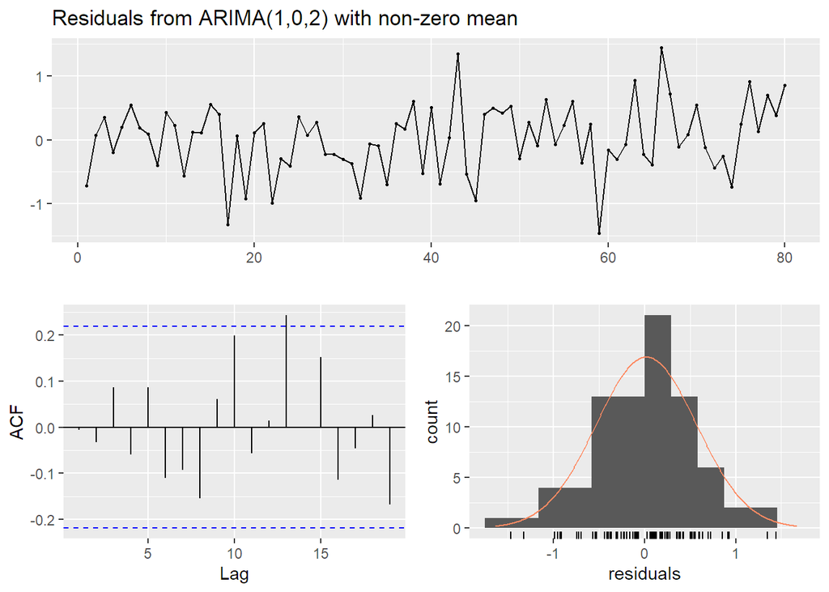

```
##
##  Ljung-Box test
##
## data:  Residuals from ARIMA(1,0,2) with non-zero mean
## Q* = 9.7478, df = 6, p-value = 0.1357
##
## Model df: 4.   Total lags used: 10
```

```r
autoplot(arimaModel_102);checkresiduals(arimaModel_102)
```

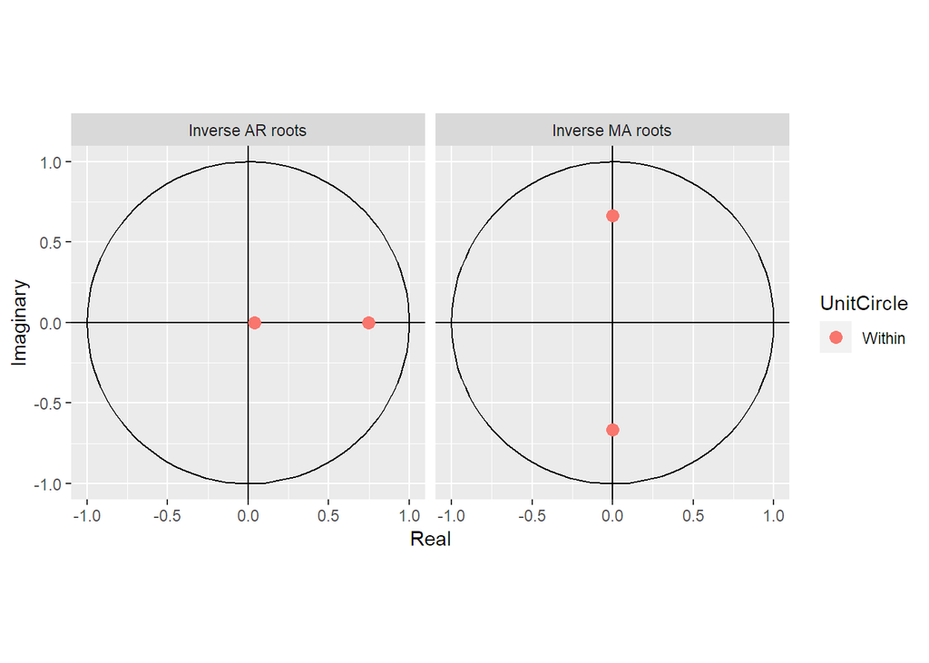

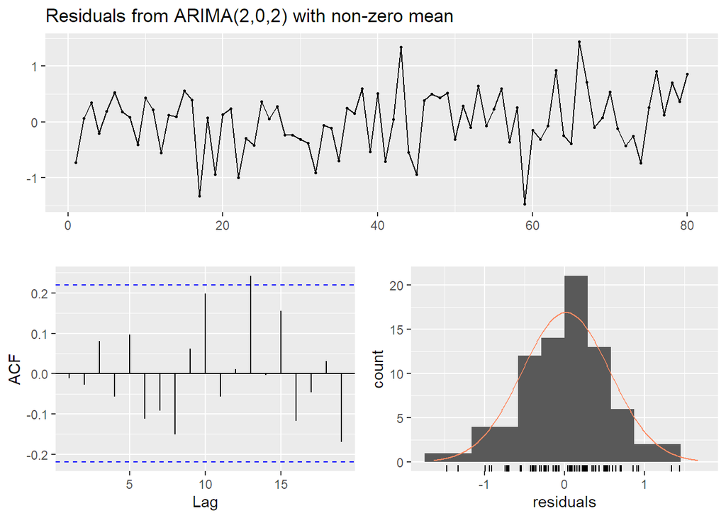

```
##
##  Ljung-Box test
##
## data:  Residuals from ARIMA(2,0,2) with non-zero mean
## Q* = 9.7188, df = 5, p-value = 0.08361
##
## Model df: 5.   Total lags used: 10
```

```r
autoplot(arimaModel_202);checkresiduals(arimaModel_202)
```

MA차수를 높인 결과 두 모델 모두 잔차의 독립성을 만족하고 정상성과 정규성 또한 모두 만족하는 것으로 보입니다. 이에 따라 두 모델을 가지고 예측을 진행하도록 하겠습니다.

##### (4) 예측 및 정확성

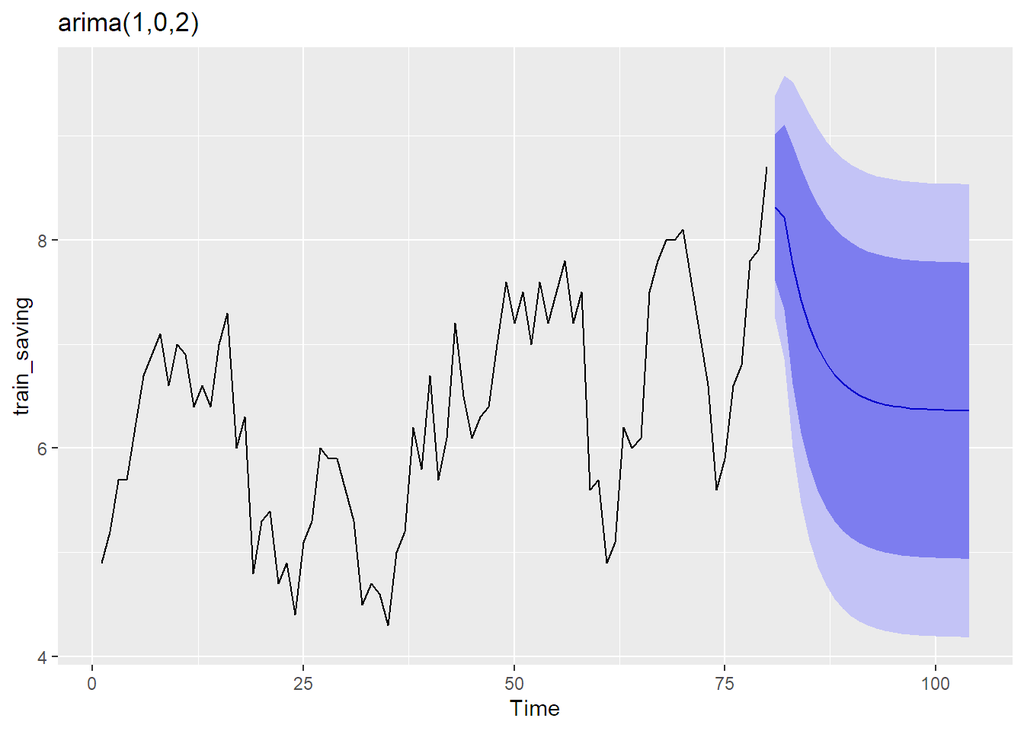

```r
forecast1 = forecast::forecast(arimaModel_102, h=24)
forecast2 = forecast::forecast(arimaModel_202, h=24)

autoplot(forecast1) + ggtitle("arima(1,0,2)")
```

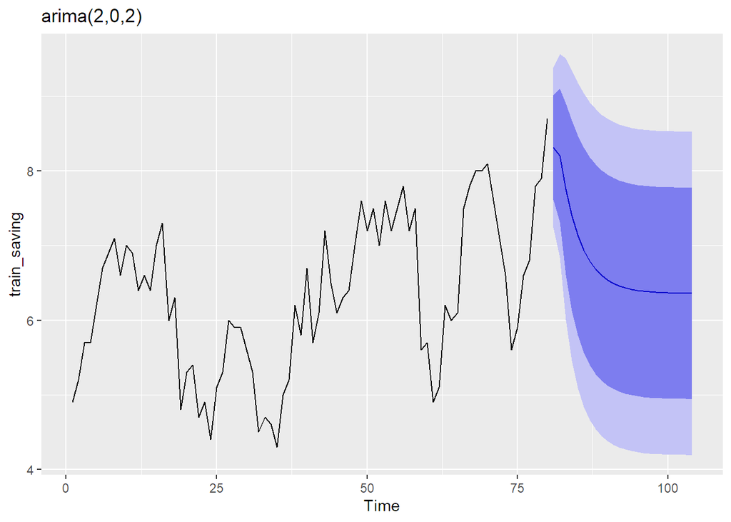

```r
autoplot(forecast2) + ggtitle("arima(2,0,2)")
```

```r
accuracy(arimaModel_102)
```

```
##                      ME      RMSE       MAE        MPE     MAPE      MASE
## Training set 0.01932757 0.5474494 0.4332655 -0.4749327 7.043337 0.9055019
##                      ACF1
## Training set -0.006043453
```

```r
accuracy(arimaModel_202)
```

```
##                      ME      RMSE       MAE        MPE     MAPE      MASE
## Training set 0.01893835 0.5474252 0.4334542 -0.4845584 7.049504 0.9058964
##                     ACF1
## Training set -0.01170381
```

*RMSE : 여러 정확성 나타내는 지표 중 하나로 작을수록 정확성이 높다고 판단합니다.*

##### (5) test data 예측값, 실제값 비교

```r
df.forecast2 = data.frame(forecast2)
regr.eval(test_saving, df.forecast2$Point.Forecast)
```

```
##       mae       mse      rmse      mape
## 1.2107388 1.9631215 1.4011144 0.2338919
```

RMSE가 1.4011으로 0에 가깝지는 않아 예측 성능이 좋은 것은 아니지만 어느 정도의 예측성능은 이루어진 것 같습니다.

### 4. INGA_AmsterdamDiff

INGA.AmsterdamDiff 데이터는 2010년 1월1일부터 257일간, 주가의 일별 변화에 대한 데이터입니다.  
예측을 위한 ARIMA 모델 선택을 위해 INGA.AmsterdamDiff 데이터의 여러 특징을 알아보고 가장 좋은 모델을 최종 선택하겠습니다.

#### [STEP 1] 시계열 데이터 처리

2010년 1월 1일부터 하루 주기로 측정한 주가의 변화임을 고려하여 시계열 데이터로 변환합니다.

```r
inga = read.table("INGA_AmsterdamDiff.txt")
inga_ts = ts(inga, start=1, frequency=1)
```

#### [STEP 2] 시계열 그래프

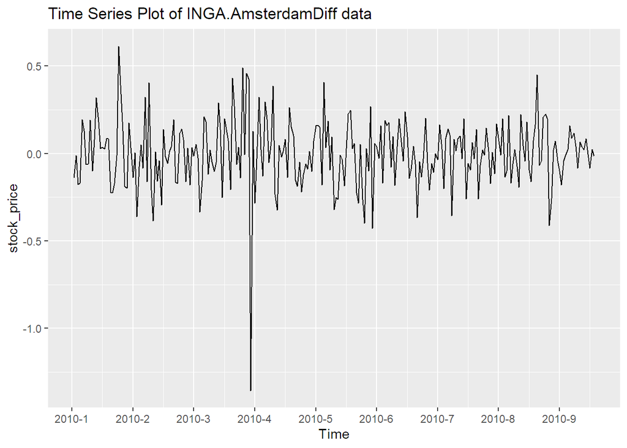

```r
date=seq(0,nrow(inga_ts),by=30)
autoplot(inga_ts) + ylab("stock_price") +
  ggtitle("Time Series Plot of INGA.AmsterdamDiff data") +
  scale_x_continuous(breaks=date, labels=paste0("2010-",date/30+1 ))
```

2010년 4월로 넘어가며 급격히 주식이 한번 하락하였으나  
대부분 변화율이 0%에서 왔다 갔다하며 어떠한 추세,계절성과 같은 특징이 전혀 보이지 않습니다.

#### [STEP 3] ACF, PACF

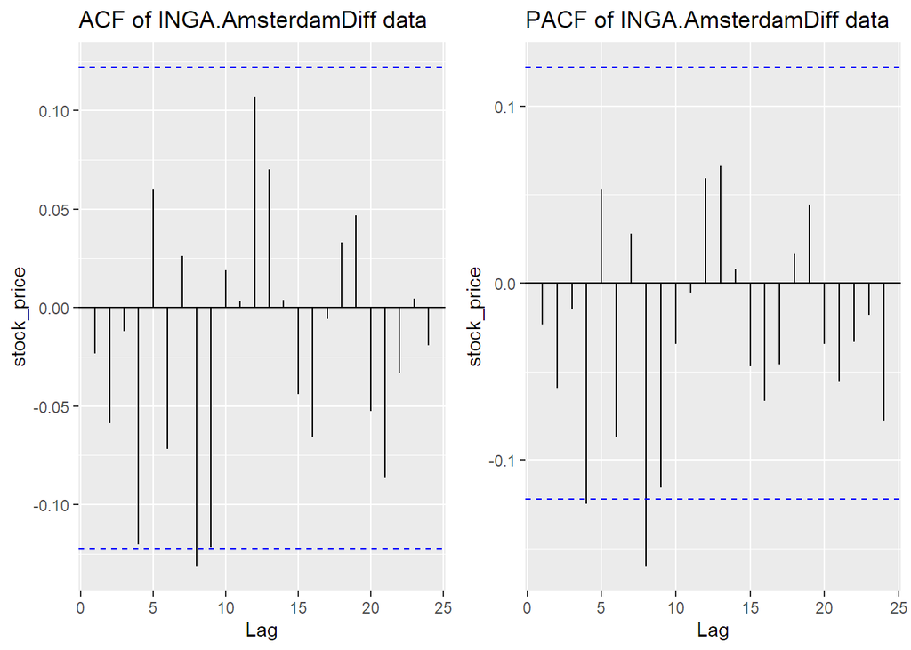

```r
p1 = ggAcf(inga_ts) + ylab("stock_price") + ggtitle("ACF of INGA.AmsterdamDiff data")
p2 = ggPacf(inga_ts) + ylab("stock_price") + ggtitle("PACF of INGA.AmsterdamDiff data")
grid.arrange(p1, p2, ncol=2)
```

ACF, PACF 모두 유의수준에서 거의 벗어나지 않습니다.  
이는 자기상관성이 없는 잔차와 같은 White noise, $Y_t$ = $a_t$, $a_t$:WN 에 해당하는 것으로 보입니다.

AutoarimaModel은 어떤 모델을 추정하는 지에 대해 확인해봅니다.

```r
train_inga = inga_ts[1:210]
test_inga = carrot_ts[201:257]
AutoarimaModel = auto.arima(train_inga); print(AutoarimaModel)
```

```
## Series: train_inga
## ARIMA(0,0,0) with zero mean
##
## sigma^2 estimated as 0.04218:  log likelihood=34.43
## AIC=-66.85   AICc=-66.83   BIC=-63.51
```

마찬가지로 ARIMA(0,0,0) 즉 white noise로 추정하였습니다.

#### White Noise

white noise의 경우 정상성 시계열의 대표적인 예로 각 시점의 관측값이 잔차와 같은 역할입니다.  
즉, t시점에서의 관측값이 t-1시점에서의 관측값에 전혀 영향을 받지 않습니다. 이에 따라 INGA.AmsterdamDiff data에 대한 모델링은 의미가 없습니다.